# Project Coursera Practical Machine Learning

Jose Antonio

September, 2016

## Predictions using the Weight Lifting Exercises Dataset

[GitHub link for Project]https://github.com/joseantonio11/Coursera-Practical-Machine-Learning

## 1 - Summary

Using devices such as Jawbone Up, Nike FuelBand, and Fitbit it is now possible to collect a large amount of data about personal activity relatively inexpensively. These type of devices are part of the quantified self movement ??? a group of enthusiasts who take measurements about themselves regularly to improve their health, to find patterns in their behavior, or because they are tech geeks.

One thing that people regularly do is quantify how much of a particular activity they do, but they rarely quantify how well they do it. In this project, your goal will be to use data from accelerometers on the belt, forearm, arm, and dumbell of 6 participants. They were asked to perform barbell lifts correctly and incorrectly in 5 different ways. More information is available from the website here: http://groupware.les.inf.puc-rio.br/har (see the section on the Weight Lifting Exercise Dataset).

This project has the purpose to predict the manner in which users perform the exercises. There are 5 possible results, reported in the `classe` variable:

- A: exactly according to the specification
- B: throwing the elbows to the front
- C: lifting the dumbbell only halfway
- D: lowering the dumbbell only halfway
- E: throwing the hips to the front

[Read more: ]http://groupware.les.inf.puc-rio.br/har#ixzz4KEWLKYo1

The data for the project is available at:

[Training Dataset: ]https://d396qusza40orc.cloudfront.net/predmachlearn/pml-training.csv

[Testing Dataset: ]https://d396qusza40orc.cloudfront.net/predmachlearn/pml-testing.csv

The objective of this project is to predict the `classe` based on data from accelerometers on the belt, forearm, arm, and dumbell of 6 participants.

## 2 - Libraries

```r
library(knitr)
knitr::opts_chunk$set(echo = TRUE, warning=FALSE, message=FALSE, fig.width=10, fig.height=5)
options(width=120)
library(lattice); library(ggplot2); library(plyr)
library(caret); library(randomForest); library(rpart);library(rpart.plot); library(tree)
library(rattle)
set.seed(6266) # set contact random seed
```

## 3 - Dataset Loading

```r
trainUrl <- "https://d396qusza40orc.cloudfront.net/predmachlearn/pml-training.csv"
testUrl <- "https://d396qusza40orc.cloudfront.net/predmachlearn/pml-testing.csv"
download.file(trainUrl, "pml-training.csv",  method="curl")
download.file(testUrl, "pml-testing.csv",  method="curl")
rm(trainUrl); rm(testUrl)
```

## 4 - Wrangling Dataset

Organizing a new dataset with only the data that is necessary for EDA and ML Training data.

```r
## Reading dataset and replacing NA Strings with NA
training <- read.csv("pml-training.csv", na.strings=c("NA","#DIV/0!",""))
testing <- read.csv("pml-testing.csv", na.strings=c("NA","#DIV/0!",""))
dim(training); dim(testing)
```

```
## [1] 19622   160
```

```
## [1]  20 160
```

```r
##  Some variables (7 first columns with 'X', 'user_name', 'raw_timestamp_part_1', 'raw_timestamp_part_2',
##  'cvtd_timestamp', 'new_window', 'num_window') can be deleted because will not useful to this Project.
training <- training[,-c(1:7)]
testing <- testing[,-c(1:7)]
dim(training); dim(testing)
```

```
## [1] 19622   153
```

```
## [1]  20 153
```

```r
# Delete columns with all missing values
training <- training[ , colSums(is.na(training)) == 0]
testing <- testing[ , colSums(is.na(testing)) == 0]
dim(training); dim(testing)
```

```
## [1] 19622    53
```

```
## [1] 20 53
```

With our cleanup, as you can see, now we have a reduced number of variables, that will be used for analysis.

## 5 - Plotting Dataset for EDA

This project has purpose to predict the manner in which users perform the exercises based on varialbe `classe` classified as A,B,C,D and E.

Lets use the variable `classe` in the plot, to see the frequency of each levels in training dataset.

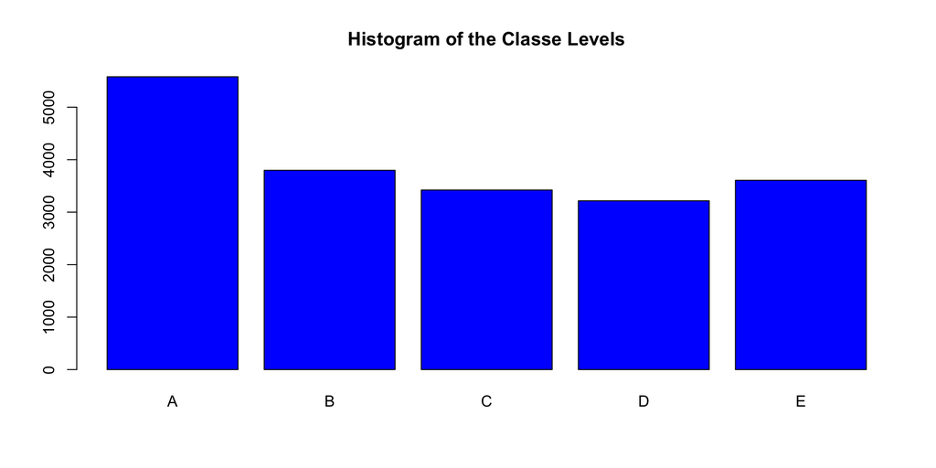

```r
plot(training$classe, col = "blue", main="Histogram of the Classe Levels")
```

The A classe seems to be the most frequent and D classe the least.

## 6 - Partition Training Dataset

To enable cross-validation lets make two subsets using 70% for Training and 30% for Testing. This method will allow us to apply ML Prediction Models and evaluate bias and variance.

```r
partition <- createDataPartition(y=training$classe, p=0.7, list=FALSE)
trainingSet <- training[partition, ]
testingSet <- training[-partition, ]
rm(partition)
```

## 7 - Predictions Models

Lets implement the Regression Tree model and Random Forest.

Decision tree model is good for classification problems.

```r
treeFit=tree(classe~.,data=trainingSet) # Tree package
summary(treeFit)
```

```
##
## Classification tree:
## tree(formula = classe ~ ., data = trainingSet)
## Variables actually used in tree construction:
##  [1] "roll_belt"            "pitch_forearm"        "roll_forearm"         "magnet_dumbbell_x"    "magnet_dumbbell_y"
##  [6] "magnet_dumbbell_z"    "pitch_belt"           "yaw_belt"             "accel_dumbbell_x"     "accel_dumbbell_z"
## [11] "total_accel_dumbbell" "magnet_forearm_z"     "accel_forearm_x"
## Number of terminal nodes:  18
## Residual mean deviance:  1.693 = 23230 / 13720
## Misclassification error rate: 0.3288 = 4517 / 13737
```

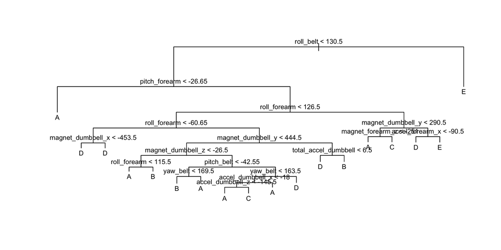

```r
plot(treeFit)
text(treeFit,pretty=0, cex =.8)
```

### 7.2 - RPart from the Caret package.

```r
rpartFit <- train(classe ~ .,method="rpart",data=trainingSet) # library Caret
print(rpartFit$finalModel)
```

```
## n= 13737
##
## node), split, n, loss, yval, (yprob)
##       * denotes terminal node
##
##  1) root 13737 9831 A (0.28 0.19 0.17 0.16 0.18)
##    2) roll_belt< 130.5 12575 8682 A (0.31 0.21 0.19 0.18 0.11)
##      4) pitch_forearm< -26.65 1221   47 A (0.96 0.038 0 0 0) *
##      5) pitch_forearm>=-26.65 11354 8635 A (0.24 0.23 0.21 0.2 0.12)
##       10) yaw_belt>=169.5 562   60 A (0.89 0.046 0 0.057 0.0036) *
##       11) yaw_belt< 169.5 10792 8207 B (0.21 0.24 0.22 0.21 0.13)
##         22) magnet_dumbbell_z< -88.5 1432  600 A (0.58 0.27 0.049 0.073 0.024) *
##         23) magnet_dumbbell_z>=-88.5 9360 7034 C (0.15 0.23 0.25 0.23 0.14)
##           46) pitch_belt< -42.95 582   93 B (0.012 0.84 0.093 0.027 0.027) *
##           47) pitch_belt>=-42.95 8778 6506 C (0.16 0.19 0.26 0.24 0.15)
##             94) magnet_dumbbell_x>=-446.5 3774 2617 B (0.17 0.31 0.096 0.24 0.19) *
##             95) magnet_dumbbell_x< -446.5 5004 3096 C (0.15 0.11 0.38 0.24 0.12) *
##    3) roll_belt>=130.5 1162   13 E (0.011 0 0 0 0.99) *
```

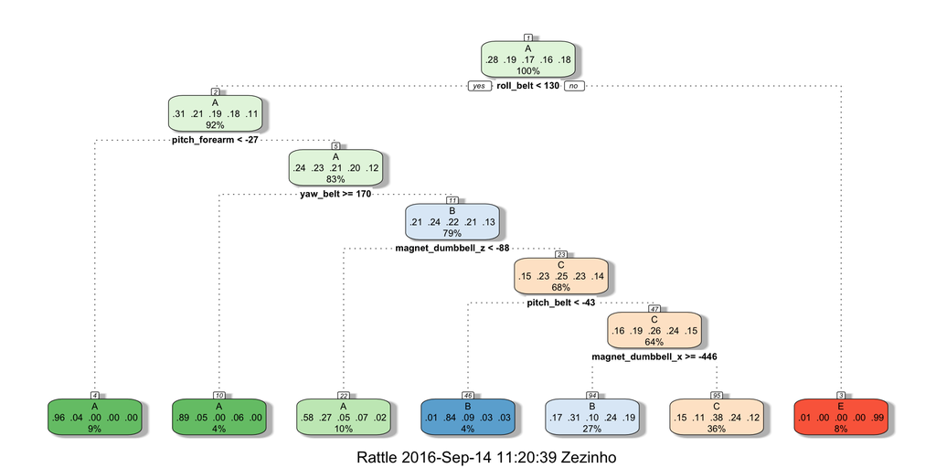

```r
fancyRpartPlot(rpartFit$finalModel) # library Rattle
```

Rpart has a little much accurate result than Tree. Rpart has some methods, and one of them is `class` with good precision. Lets try it. te. See below.

[figure not shown]

```r
classFit <- rpart(classe ~ ., data=trainingSet, method="class") # library caret
fancyRpartPlot(classFit, sub = "") #library Rattle
```

[output not shown]

Now,lets see how well it is predicting our test data:

```r
predict1 <- predict(classFit, testingSet, type = "class")
cmatrix1 <- confusionMatrix(predict1, testingSet$classe)
cmatrix1
```

```
## Confusion Matrix and Statistics
##
##           Reference
## Prediction    A    B    C    D    E
##          A 1386  166   18   39   46
##          B   43  543   47   66   32
##          C   32  112  696   48   52
##          D  201  184  211  708  188
##          E   12  134   54  103  764
##
## Overall Statistics
##
##                Accuracy : 0.6962
##                  95% CI : (0.6842, 0.7079)
##     No Information Rate : 0.2845
##     P-Value [Acc > NIR] : < 2.2e-16
##
##                   Kappa : 0.617
##  Mcnemar's Test P-Value : < 2.2e-16
##
## Statistics by Class:
##
##                      Class: A Class: B Class: C Class: D Class: E
## Sensitivity            0.8280  0.47673   0.6784   0.7344   0.7061
## Specificity            0.9361  0.96039   0.9498   0.8407   0.9369
## Pos Pred Value         0.8375  0.74282   0.7404   0.4745   0.7160
## Neg Pred Value         0.9319  0.88436   0.9333   0.9417   0.9340
## Prevalence             0.2845  0.19354   0.1743   0.1638   0.1839
## Detection Rate         0.2355  0.09227   0.1183   0.1203   0.1298
## Detection Prevalence   0.2812  0.12421   0.1597   0.2535   0.1813
## Balanced Accuracy      0.8820  0.71856   0.8141   0.7876   0.8215
```

The accuracy shows a good results using Rpart, but a great Regression Method, used for resolution of problems in Kaggle, is Random Forests. Lets apply it now into our Project.

### 7.3 - Random Forest

```r
modelRandom <- randomForest(classe ~. , data=trainingSet, method="class")

# Prediction Model
modelpred <- predict(modelRandom, testingSet, type = "class")

# Test results on our testingSet
confusionMatrix(modelpred, testingSet$classe)
```

```
## Confusion Matrix and Statistics
##
##           Reference
## Prediction    A    B    C    D    E
##          A 1673    1    0    0    0
##          B    1 1137    4    0    0
##          C    0    1 1021   12    1
##          D    0    0    1  951    3
##          E    0    0    0    1 1078
##
## Overall Statistics
##
##                Accuracy : 0.9958
##                  95% CI : (0.9937, 0.9972)
##     No Information Rate : 0.2845
##     P-Value [Acc > NIR] : < 2.2e-16
##
##                   Kappa : 0.9946
##  Mcnemar's Test P-Value : NA
##
## Statistics by Class:
##
##                      Class: A Class: B Class: C Class: D Class: E
## Sensitivity            0.9994   0.9982   0.9951   0.9865   0.9963
## Specificity            0.9998   0.9989   0.9971   0.9992   0.9998
## Pos Pred Value         0.9994   0.9956   0.9865   0.9958   0.9991
## Neg Pred Value         0.9998   0.9996   0.9990   0.9974   0.9992
## Prevalence             0.2845   0.1935   0.1743   0.1638   0.1839
## Detection Rate         0.2843   0.1932   0.1735   0.1616   0.1832
## Detection Prevalence   0.2845   0.1941   0.1759   0.1623   0.1833
## Balanced Accuracy      0.9996   0.9986   0.9961   0.9929   0.9980
```

As seen by the result of the confusionmatrix, the accuracy for random forests was 0.9958 (very good sensitivity and specificity values) whereas the decision tree was 0.69. The accuracy is above 99% for the random forest model in our cross-validation data with few misclassifications as compared to the decision tree model.

## 8 - Submission Data for Grading

### 8.1 - Trained Model on the Twenty Testing Data

Random Forests was the choose for this project. Lets apply it to our Testing dataset using the predictor on the test data.

```r
answersubmission <- predict(modelRandom, testing, type="class")
answersubmission
```

```
##  1  2  3  4  5  6  7  8  9 10 11 12 13 14 15 16 17 18 19 20
##  B  A  B  A  A  E  D  B  A  A  B  C  B  A  E  E  A  B  B  B
## Levels: A B C D E
```

The answer above is the model machine learning algorithm applyied to the 20 test cases availabe in the test data. It scores 100% of the submission (the 20 values to be predict), that will be submitted to answer the questions of Course Project Prediction Quiz.